# An AI-Assisted Self-Building Protest Database

IASSIST 2026

Johannes B. Gruber (GESIS); Corinna Hertweck (U Zürich); Marius Sältzer (U Oldenburg)

2025-06-03

## Why a new protest database?

- Currently, no centralized database of protests in Germany
- Different sources of information:
  - Newspaper coverage
  - Social media
  - Flyers
  - etc.
- Centralized DB would be valuable!

⟶ public, journalists & researchers

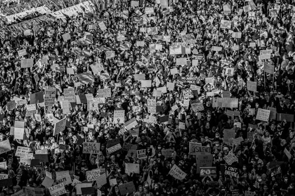

[Teemu Paananen](https://unsplash.com/@xteemu) via unsplash.com

### Questions on protests

- How do police respond to different types of protests?
- Can we track specific movements (e.g., Fridays for Future) and see their growth or spread?
- How do slogans, messaging or framing vary within a movement over time or across regions?

### Questions on reporting

- Are certain outlets systematically over- or underreporting?
- How does the media report on/frame (different) protests?
- Can we derive a quantification of media bias from the reporting on crowd sizes?

## Data Pipeline

## Overview

### Step 1

FreshRSS…

- … retrieves 74 RSS feeds of German newspapers…
- … puts title, content blurb, author and **URL** in PostgreSQL database…

… every 10 minutes

### Step 1.5

Helper script…

- … filters for `"protest|demonstr"` in title, text, and tags
- … copies data to AmCAT (Elasticsearch with user access control)

### Step 2

Paperboy:

1. retrieves URLs from AmCAT
2. downloads full HTML from news site
3. parses out headline, author, full article text
4. saves results to AmCAT (updates entries)

[`paperboy`: R package with custom parsers for 182 news sites; monitored daily]

### Step 3

A local **qwen3.5:9b** model (via Ollama) classifies each event.

- Zero-shot classification
- Runs fully offline — no API calls, no costs
- Output: structured JSON labels -> AmCAT

### Step 4

Public dashboard:

- all variables visible for everyone – except full texts
- news articles and variables fully searchable
- aggregation of variables as plots or csv

## Dashboard

[figure not shown]

https://protest.jbgruber.online/projects/de-news

## Repo

[figure not shown]

https://github.com/JBGruber/protest-news

### Summary

The full data pipeline is open source and available on GitHub.

- All parts are available as reproducible docker container
- No costs, except for compute
- Runs on single computer (12 cores, 64GB RAM, RTX 3060 (12GB VRAM))
- Automatically growing dataset
- A public as possible (Except full news texts)

## Wider context

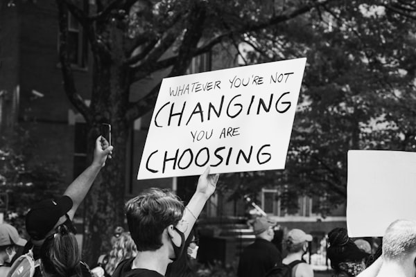

[Corey Young](https://unsplash.com/@corey_untitled) via unsplash.com

- Ongoing project about information uncertainty and news sources
- Open question:
  - how can we “merge” events?
  - can we quantify uncertainty?
  - can we quantify media bias?